# Multiple sequence alignments, and profile hidden Markov models

The hits are sorted by increasing E-value of the full sequence, which correlates with decreasing score.

Note that **E-values are dependent on the size of the database, while scores are not**! Therefore, it is preferable to use scores as model cutoffs.

To efficiently explore the long sprot_Rab_hits_hmmsearch.out file, we will $grep$ out the lines containing the human, dicty and Arabidopsis annotations, and simplify the output with some $AWK$ code.

```bash
# identify the highest alignment and domain E-values and scores to be used as cutoffs,
#   based on the human, dicty, and Arabidopsis Rab swiss-prot annotations
grep sapiens sprot_Rab_hits_hmmsearch.out | awk '{print $1,$5,$6,$19,$20,$21,$22,$23,$24,$25}' | grep -E 'Rab|RAB' | column -t # major score drop 165.8 -> 77.9; score 165
grep Arabidopsis sprot_Rab_hits_hmmsearch.out |  awk '{print $1,$5,$6,$19,$20,$21,$22,$23,$24,$25}' | grep -E 'Rab|RAB' | column -t # 1.7e-50  177.2
grep Dictyostelium sprot_Rab_hits_hmmsearch.out |  awk '{print $1,$5,$6,$19,$20,$21,$22,$23,$24,$25}' | grep -E 'Rab|RAB' | column -t # 4.9e-45  score 159
```

```
# grep sapiens sprot_Rab_hits_hmmsearch.out | awk '{print $1,$5,$6,$19,$20,$21,$22,$23,$24,$25}' | grep -E 'Rab|RAB' | column -t | tail
sp|Q969Q5|RAB24_HUMAN  1.7e-65   226.5  Ras-related  protein      Rab-24        OS=Homo  sapiens  GN=RAB24    PE=1
sp|P51157|RAB28_HUMAN  5e-65     225.0  Ras-related  protein      Rab-28        OS=Homo  sapiens  GN=RAB28    PE=1
sp|Q7Z6P3|RAB44_HUMAN  2.2e-61   213.0  Ras-related  protein      Rab-44        OS=Homo  sapiens  GN=RAB44    PE=3
sp|Q9NX57|RAB20_HUMAN  6.2e-53   185.2  Ras-related  protein      Rab-20        OS=Homo  sapiens  GN=RAB20    PE=1
------------------------------------------------------------------------------------------------------------------------ STRICT CUTOFF, ONLY CANONICAL RABs
sp|Q9UBK7|RBL2A_HUMAN  1.4e-47   167.6  Rab-like     protein      2A            OS=Homo  sapiens  GN=RABL2A   PE=2
sp|Q9UNT1|RBL2B_HUMAN  4.8e-47   165.8  Rab-like     protein      2B            OS=Homo  sapiens  GN=RABL2B   PE=2
------------------------------------------------------------------------------------------------------------------------ RELAXED CUTOFF, including RAB-like proteins, before large score drop.
sp|Q8N4Z0|RAB42_HUMAN  2.7e-20   77.9   Putative     Ras-related  protein       Rab-42   OS=Homo  sapiens     GN=RAB42
sp|Q5HYI8|RABL3_HUMAN  3.3e-16   64.5   Rab-like     protein      3             OS=Homo  sapiens  GN=RABL3    PE=1
sp|Q3YEC7|RABL6_HUMAN  2.8e-11   48.3   Rab-like     protein      6             OS=Homo  sapiens  GN=RABL6    PE=1
sp|Q9BU20|RSG1_HUMAN   7.7e-07   33.6   REM2-        and          Rab-like      small    GTPase   1           OS=Homo
```

Based on the output of the $grep$ command on the human hits shown above, a reasonably relaxed sequence score to find most Rab and Rab-like homologs, without including too many false positives, would lie around 165.

```
# grep Arabidopsis sprot_Rab_hits_hmmsearch.out | awk '{print $1,$5,$6,$19,$20,$21,$22,$23,$24,$25}' | column -t
... truncated
sp|Q9C820|RAG3D_ARATH  1e-73    253.5  Ras-related       protein             RABG3d       OS=Arabidopsis  thaliana        GN=RABG3D       PE=2
sp|Q9SJ11|RABG2_ARATH  3.9e-73  251.6  Ras-related       protein             RABG2        OS=Arabidopsis  thaliana        GN=RABG2        PE=2
sp|Q9SF92|RAC2B_ARATH  5.4e-72  247.9  Ras-related       protein             RABC2b       OS=Arabidopsis  thaliana        GN=RABC2B       PE=2
sp|Q9LW76|RAG3C_ARATH  5.9e-72  247.7  Ras-related       protein             RABG3c       OS=Arabidopsis  thaliana        GN=RABG3C       PE=2
sp|O04157|RAG3B_ARATH  8.4e-72  247.2  Ras-related       protein             RABG3b       OS=Arabidopsis  thaliana        GN=RABG3B       PE=1
sp|Q9LV79|RAH1A_ARATH  1.1e-71  246.9  Ras-related       protein             RABH1a       OS=Arabidopsis  thaliana        GN=RABH1A       PE=2
sp|Q948K8|RAG3A_ARATH  1.5e-71  246.5  Ras-related       protein             RABG3a       OS=Arabidopsis  thaliana        GN=RABG3A       PE=2
sp|Q9XI98|RAG3E_ARATH  2e-71    246.0  Ras-related       protein             RABG3e       OS=Arabidopsis  thaliana        GN=RABG3E       PE=2
sp|Q948K6|RABG1_ARATH  1.7e-65  226.5  Ras-related       protein             RABG1        OS=Arabidopsis  thaliana        GN=RABG1        PE=2
----------------------------------------------------------------------------------------------------------------------------------------------------- Strong score drop
sp|Q9SJZ5|RAA4E_ARATH  1.7e-50  177.2  Putative          Ras-related         protein      RABA4e          OS=Arabidopsis  thaliana        GN=RABA4E
----------------------------------------------------------------------------------------------------------------------------------------------------- Ran and Rac hits if score < 163
sp|Q9FLQ3|RAN4_ARATH   5e-46    162.5  GTP-binding       nuclear             protein      Ran-4           OS=Arabidopsis  thaliana        GN=RAN4
sp|P41916|RAN1_ARATH   7.8e-46  161.9  GTP-binding       nuclear             protein      Ran-1           OS=Arabidopsis  thaliana        GN=RAN1
sp|P41917|RAN2_ARATH   1.2e-45  161.3  GTP-binding       nuclear             protein      Ran-2           OS=Arabidopsis  thaliana        GN=RAN2
sp|Q8H156|RAN3_ARATH   1.4e-45  161.0  GTP-binding       nuclear             protein      Ran-3           OS=Arabidopsis  thaliana        GN=RAN3
sp|Q9XGU0|RAC9_ARATH   3.7e-45  159.6  Rac-like          GTP-binding         protein      ARAC9           OS=Arabidopsis  thaliana        GN=ARAC9
sp|Q38912|RAC3_ARATH   5.2e-45  159.1  Rac-like          GTP-binding         protein      ARAC3           OS=Arabidopsis  thaliana        GN=ARAC3
sp|O82480|RAC7_ARATH   6.4e-45  158.9  Rac-like          GTP-binding         protein      ARAC7           OS=Arabidopsis  thaliana        GN=ARAC7
sp|P92978|RAC11_ARATH  7.6e-45  158.6  Rac-like          GTP-binding         protein      ARAC11          OS=Arabidopsis  thaliana        GN=ARAC11
... truncated
```

Careful examination of the human and *Arabidopsis* outputs shown above, suggests that a **score cutoff >= 185** would retrieve *bona fide* Rab GTPases, excluding the non-canonical, putative Rab-like proteins, and non-Rab members of the Ras superfamily.

We will evaluate the robustness and suitability of the >= 185 score cutoff by analyzing also the *Dictyostelium* and yeast output files:

```
# grep Dictyostelium sprot_Rab_hits_hmmsearch.out | awk '{print $1,$5,$6,$19,$20,$21,$22,$23,$24,$25}' | column -t
... truncated
sp|Q54SV1|RABY_DICDI   7.7e-55  191.5  Ras-related       protein                   RabY        OS=Dictyostelium  discoideum        GN=rabY           PE=3
sp|Q55EF0|RABT2_DICDI  7.8e-55  191.5  Ras-related       protein                   RabT2       OS=Dictyostelium  discoideum        GN=rabT2          PE=3
sp|Q86JC8|RABH_DICDI   2.9e-54  189.6  Ras-related       protein                   RabH        OS=Dictyostelium  discoideum        GN=rabH           PE=3
sp|Q55EG6|RABT1_DICDI  4.4e-54  189.0  Ras-related       protein                   RabT1       OS=Dictyostelium  discoideum        GN=rabT1          PE=3
-----------------------------------------------------------------------------------------------------------------------------------------------------------/ score cutoff >= 185
sp|P32254|RASS_DICDI   1.8e-52  183.7  Ras-like          protein                   rasS        OS=Dictyostelium  discoideum        GN=rasS           PE=2
sp|Q54FK7|RABL_DICDI   6.1e-51  178.7  Ras-related       protein                   RabL        OS=Dictyostelium  discoideum        GN=rabL           PE=3
sp|P15064|RASG_DICDI   1.4e-49  174.2  Ras-like          protein                   rasG        OS=Dictyostelium  discoideum        GN=rasG           PE=1
sp|P32252|RASB_DICDI   3e-49    173.1  Ras-like          protein                   rasB        OS=Dictyostelium  discoideum        GN=rasB           PE=1
sp|P18613|RAPA_DICDI   3.9e-49  172.7  Ras-related       protein                   rapA        OS=Dictyostelium  discoideum        GN=rapA           PE=1
sp|P03967|RASD_DICDI   9e-49    171.5  Ras-like          protein                   rasD        OS=Dictyostelium  discoideum        GN=rasD           PE=2
sp|P32253|RASC_DICDI   1.1e-48  171.3  Ras-like          protein                   rasC        OS=Dictyostelium  discoideum        GN=rasC           PE=2
sp|Q55CB7|RASY_DICDI   1.2e-48  171.1  Ras-like          protein                   rasY        OS=Dictyostelium  discoideum        GN=rasY           PE=3
sp|Q55BW0|RAPC_DICDI   1.8e-48  170.5  Ras-related       protein                   rapC        OS=Dictyostelium  discoideum        GN=rapC           PE=3
sp|Q54FK5|RABN1_DICDI  9.5e-48  168.1  Ras-related       protein                   RabN1       OS=Dictyostelium  discoideum        GN=rabN1          PE=3
sp|Q55CC0|RASW_DICDI   1.1e-47  167.9  Ras-like          protein                   rasW        OS=Dictyostelium  discoideum        GN=rasW           PE=3
sp|Q55CB8|RASX_DICDI   1.5e-47  167.5  Ras-like          protein                   rasX        OS=Dictyostelium  discoideum        GN=rasX           PE=3
sp|Q55CA9|RASZ_DICDI   6.4e-47  165.4  Ras-like          protein                   rasZ        OS=Dictyostelium  discoideum        GN=rasZ           PE=3
sp|Q55CB0|RASU_DICDI   1.7e-46  164.0  Ras-like          protein                   rasU        OS=Dictyostelium  discoideum        GN=rasU           PE=3
sp|Q54FG4|RABP_DICDI   2.8e-46  163.3  Ras-related       protein                   RabP        OS=Dictyostelium  discoideum        GN=rabP           PE=3
sp|Q55CB9|RASV_DICDI   1.3e-45  161.1  Ras-like          protein                   rasV        OS=Dictyostelium  discoideum        GN=rasV           PE=3
sp|P33519|RAN_DICDI    1.3e-45  161.1  GTP-binding       nuclear                   protein     Ran               OS=Dictyostelium  discoideum        GN=ranA
... truncated
```

below the *Sacharomyces* $hmmsearch$ output. Note that the yeast Rab GTPases are labeled as YPT* proteins:

```
# grep Saccharom sprot_Rab_hits_hmmsearch.out |  awk '{print $1,$5,$6,$19,$20,$21,$22,$23,$24,$25}' | column -t
sp|P01123|YPT1_YEAST   3.1e-93  317.7  GTP-binding           protein             YPT1                OS=Saccharomyces  cerevisiae        (strain           ATCC
sp|P38555|YPT31_YEAST  1e-87    299.6  GTP-binding           protein             YPT31/YPT8          OS=Saccharomyces  cerevisiae        (strain           ATCC
sp|P51996|YPT32_YEAST  7.3e-87  296.8  GTP-binding           protein             YPT32/YPT11         OS=Saccharomyces  cerevisiae        (strain           ATCC
sp|P07560|SEC4_YEAST   3e-86    294.8  Ras-related           protein             SEC4                OS=Saccharomyces  cerevisiae        (strain           ATCC
sp|Q99260|YPT6_YEAST   6e-81    277.3  GTP-binding           protein             YPT6                OS=Saccharomyces  cerevisiae        (strain           ATCC
sp|P36017|VPS21_YEAST  2e-79    272.3  Vacuolar              protein             sorting-associated  protein           21                OS=Saccharomyces  cerevisiae
sp|P32939|YPT7_YEAST   5.4e-75  257.7  GTP-binding           protein             YPT7                OS=Saccharomyces  cerevisiae        (strain           ATCC
sp|P36019|YPT53_YEAST  3.2e-74  255.2  GTP-binding           protein             YPT53               OS=Saccharomyces  cerevisiae        (strain           ATCC
sp|P36018|YPT52_YEAST  7.6e-74  254.0  GTP-binding           protein             YPT52               OS=Saccharomyces  cerevisiae        (strain           ATCC
sp|P38146|YPT10_YEAST  1.6e-59  206.9  GTP-binding           protein             YPT10               OS=Saccharomyces  cerevisiae        (strain           ATCC
sp|A6ZSH6|YPT11_YEAS7  9.6e-56  194.4  GTP-binding           protein             YPT11               OS=Saccharomyces  cerevisiae        (strain           YJM789)
sp|B5VQB6|YPT11_YEAS6  1.1e-55  194.3  GTP-binding           protein             YPT11               OS=Saccharomyces  cerevisiae        (strain           AWRI1631)
sp|P48559|YPT11_YEAST  1.1e-55  194.3  GTP-binding           protein             YPT11               OS=Saccharomyces  cerevisiae        (strain           ATCC
sp|B3LPD8|YPT11_YEAS1  1.1e-55  194.2  GTP-binding           protein             YPT11               OS=Saccharomyces  cerevisiae        (strain           RM11-1a)
-------------------------------------------------------------------------------------------------------------------------------------------------------------------- / score 185 cutoff; note also large score drop
sp|P01119|RAS1_YEAST   1.9e-48  170.5  Ras-like              protein             1                   OS=Saccharomyces  cerevisiae        (strain           ATCC
sp|P32836|GSP2_YEAST   3.6e-48  169.6  GTP-binding           nuclear             protein             GSP2/CNR2         OS=Saccharomyces  cerevisiae        (strain
sp|P32835|GSP1_YEAST   4.6e-48  169.2  GTP-binding           nuclear             protein             GSP1/CNR1         OS=Saccharomyces  cerevisiae        (strain
sp|P01120|RAS2_YEAST   1.1e-47  167.9  Ras-like              protein             2                   OS=Saccharomyces  cerevisiae        (strain           ATCC
sp|P13856|RSR1_YEAST   5e-46    162.5  Ras-related           protein             RSR1                OS=Saccharomyces  cerevisiae        (strain           ATCC
sp|Q00246|RHO4_YEAST   2e-41    147.4  GTP-binding           protein             RHO4                OS=Saccharomyces  cerevisiae        (strain           ATCC
sp|P06780|RHO1_YEAST   3.2e-41  146.7  GTP-binding           protein             RHO1                OS=Saccharomyces  cerevisiae        (strain           ATCC
sp|Q00245|RHO3_YEAST   1.1e-39  141.7  GTP-binding           protein             RHO3                OS=Saccharomyces  cerevisiae        (strain           ATCC
sp|P06781|RHO2_YEAST   1.2e-37  135.0  GTP-binding           protein             RHO2                OS=Saccharomyces  cerevisiae        (strain           ATCC
sp|P19073|CDC42_YEAST  7.9e-33  119.1  Cell                  division            control             protein           42                OS=Saccharomyces  cerevisiae
... truncated
```

**In conclusion, the score cutoff >= 185 consistently identifies canonical small Rab GTPases across highly divergent eukaryotic lineages** such as **Opisthokonta** (which includes animals like *Homo* and fungi like *Saccharomyces*), **Amoebozoa** (which includes the free-living amoeba *Dictyostelium*), and **Archaeplastida** (which includes plants like *Arabidopsis*). These results demonstrate that **careful HMM calibration ensures accurate identification of *bona fide* homologs across distantly related groups of organisms**.

Note that despite the fact that no plant sequences were included in the seed alignment of Rab GTPases used to build the Rab.hmm model, the same cutoff consistently identifies the canonical Rab GTPases in the well annotated *Arabidopsis thaliana* proteome. You can confirm this by searching the results for other organisms with well-characterized proteomes, like *Rattus* or *Bos*.

The following figure from (Burki et al. 2020; The new tree of Eukaryotes. TREE.) shows the phylogenetic position of the three supergroups **Opisthokonta**, **Amoebozoa**, and **Archaeplastida**.

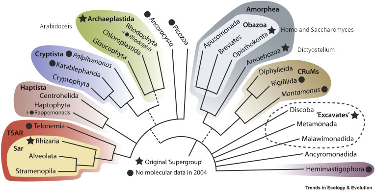

Burki et al. 2020. The new tree of Eukaryotes. TREE Volume 35, Issue 1, p43-55.

### 6.3.5 Identify Rab GTPases in the *Acanthamoeba castellanii* proteome with $hmmsearch$ using the Rab.hmm and empirically determined score cutoff

In the previous section we concluded that a **score cutoff >= 185** should retrieve *bona fide* Rab GTPases in a $hmmsearch$ using our Rab.hmm model.

The line below shows how to display the $hmmsearch$ help, and how to **set the score threshold for the output file with $-T$** in a search for canonical Rab GTPases in the poorly characterized proteome of the amoebozan *Acanthamoeba castellanii*. Its proteome is saved in the ACACA.faa file.

```bash
# hmmsearch -h
# hmmsearch :: search profile(s) against a sequence database
# HMMER 3.4 (Aug 2023); http://hmmer.org/
# Copyright (C) 2023 Howard Hughes Medical Institute.
# Freely distributed under the BSD open source license.
# - - - - - - - - - - - - - - - - - - - - - - - - - - - - - - - - - - - -
# Usage: hmmsearch [options] <hmmfile> <seqdb>
# ... truncated
#Options controlling reporting thresholds:
#  -E <x>     : report sequences <= this E-value threshold in output  [10.0]  (x>0)
#  -T <x>     : report sequences >= this score threshold in output
#  --domE <x> : report domains <= this E-value threshold in output  [10.0]  (x>0)
#  --domT <x> : report domains >= this score cutoff in output
# ... truncated
hmmsearch --tblout ACACA_Rab_hits_hmmsearch.out --noali --notextw -T 185 Rab.hmm ACACA.faa
```

#### 6.3.5.1 Count the $hmmsearch$ hits, and explore their sequence E-values and scores

```bash
grep '^tr' ACACA_Rab_hits_hmmsearch.out | wc -l ## 58
grep '^tr' ACACA_Rab_hits_hmmsearch.out | awk '{print $1,$5,$6,$19,$20,$21,$22,$23,$24,$25}' | column -t
```

```
tr|L8HD31|L8HD31_ACACA  7.1e-90  301.5  Rasrelated        protein      ORAB-1,          putative         OS=Acanthamoeba  castellanii      str.
tr|L8GSP6|L8GSP6_ACACA  1.1e-88  297.7  Ras-related       protein      Rab-2A,          putative         OS=Acanthamoeba  castellanii      str.
tr|L8HJ43|L8HJ43_ACACA  2.8e-88  296.3  RAB11B            protein,     putative         OS=Acanthamoeba  castellanii      str.             Neff
tr|L8H946|L8H946_ACACA  7.5e-84  281.7  Ras-related       protein      Rab-14           OS=Acanthamoeba  castellanii      str.             Neff
tr|L8H2N2|L8H2N2_ACACA  1.6e-82  277.3  Rasrelated        protein      Rab-2B,          putative         OS=Acanthamoeba  castellanii      str.
tr|L8H896|L8H896_ACACA  2.9e-81  273.2  RAB1B,            member       RAS              oncogene         family           OS=Acanthamoeba  castellanii
tr|L8GH28|L8GH28_ACACA  5.9e-81  272.2  Ras               subfamily    protein          OS=Acanthamoeba  castellanii      str.             Neff
tr|L8GYY7|L8GYY7_ACACA  9.8e-81  271.5  Rasrelated        protein      Rab-18-like,     putative         OS=Acanthamoeba  castellanii      str.
tr|L8HGZ3|L8HGZ3_ACACA  1.4e-80  271.0  Rab8/RabEfamily   small        GTPase,          putative         OS=Acanthamoeba  castellanii      str.
tr|L8HAR7|L8HAR7_ACACA  3.4e-80  269.7  Rab               GTPase,      putative         OS=Acanthamoeba  castellanii      str.             Neff
tr|L8GIC5|L8GIC5_ACACA  5.7e-80  269.0  Ras               family       protein          OS=Acanthamoeba  castellanii      str.             Neff
tr|L8GX62|L8GX62_ACACA  1.7e-78  264.1  Ras               family       GTP-binding      protein          YPT1             OS=Acanthamoeba  castellanii
tr|L8GN15|L8GN15_ACACA  2.4e-78  263.6  GTPbinding        protein      OS=Acanthamoeba  castellanii      str.             Neff             OX=1257118
tr|L8GPH2|L8GPH2_ACACA  3.6e-78  263.0  Rab7/RabGfamily   small        GTPase           OS=Acanthamoeba  castellanii      str.             Neff
tr|L8GK29|L8GK29_ACACA  8e-78    261.9  Ras               subfamily    protein          OS=Acanthamoeba  castellanii      str.             Neff
tr|L8HIJ7|L8HIJ7_ACACA  4.1e-77  259.6  Ras-related       protein      Rab-2-B          OS=Acanthamoeba  castellanii      str.             Neff
tr|L8HCK2|L8HCK2_ACACA  8.9e-77  258.5  RAB4,             putative     OS=Acanthamoeba  castellanii      str.             Neff             OX=1257118
tr|L8HGB4|L8HGB4_ACACA  3.9e-75  253.1  RabE              family       small            GTPase           (Fragment)       OS=Acanthamoeba  castellanii
tr|L8HAC7|L8HAC7_ACACA  1.9e-73  247.6  Ras-related       protein      Rab              OS=Acanthamoeba  castellanii      str.             Neff
tr|L8GYQ2|L8GYQ2_ACACA  2.3e-73  247.3  Raslike           GTP-binding  protein          YPT1,            putative         OS=Acanthamoeba  castellanii
tr|L8GXM9|L8GXM9_ACACA  4.4e-72  243.0  GTPbinding        protein      YPTC5,           putative         OS=Acanthamoeba  castellanii      str.
tr|L8GU59|L8GU59_ACACA  7.5e-72  242.3  Ras               subfamily    protein          OS=Acanthamoeba  castellanii      str.             Neff
tr|L8GKG8|L8GKG8_ACACA  7.9e-72  242.2  Rasrelated        protein      Rab5,            putative         OS=Acanthamoeba  castellanii      str.
... truncated
tr|L8GLA9|L8GLA9_ACACA  5.5e-62  209.8  Likely            rab          family           GTPbinding       protein          OS=Acanthamoeba  castellanii
tr|L8H5G9|L8H5G9_ACACA  9.1e-62  209.1  Ras               subfamily    protein          OS=Acanthamoeba  castellanii      str.             Neff
tr|L8H0T2|L8H0T2_ACACA  1.1e-59  202.2  Ras               subfamily    protein          OS=Acanthamoeba  castellanii      str.             Neff
tr|L8GR44|L8GR44_ACACA  1.2e-59  202.2  Ras               subfamily    protein          OS=Acanthamoeba  castellanii      str.             Neff
tr|L8GX96|L8GX96_ACACA  2.9e-59  200.9  Ras-related       protein      Rab              OS=Acanthamoeba  castellanii      str.             Neff
tr|L8GU85|L8GU85_ACACA  8.9e-59  199.3  Ras               family       protein          OS=Acanthamoeba  castellanii      str.             Neff
tr|L8HD72|L8HD72_ACACA  1.3e-58  198.7  Small             rabrelated   GTPase           OS=Acanthamoeba  castellanii      str.             Neff
tr|L8GYC3|L8GYC3_ACACA  1.2e-56  192.3  Rab1,             putative     OS=Acanthamoeba  castellanii      str.             Neff             OX=1257118
tr|L8HER3|L8HER3_ACACA  1.5e-56  192.0  Ras               subfamily    protein          OS=Acanthamoeba  castellanii      str.             Neff
tr|L8GII8|L8GII8_ACACA  4.8e-56  190.3  Ras               subfamily    protein          OS=Acanthamoeba  castellanii      str.             Neff
tr|L8HB60|L8HB60_ACACA  6.7e-56  189.8  PH                domain       containing       protein          OS=Acanthamoeba  castellanii      str.
tr|L8GVE2|L8GVE2_ACACA  8.3e-56  189.5  Ras               subfamily    protein          OS=Acanthamoeba  castellanii      str.             Neff
tr|L8H1Y4|L8H1Y4_ACACA  3.2e-55  187.6  Rabtype           small        GTP-binding      protein          OS=Acanthamoeba  castellanii      str.
tr|L8HGU8|L8HGU8_ACACA  8.7e-55  186.2  Ras               family       protein          OS=Acanthamoeba  castellanii      str.             Neff
```

The output displayed above reveals the much poorer quality, and high inconsistency, of the protein annotations of the *A. castellanii* proteome, which reflects the fact that none of these proteins is yet in [Swiss-Prot](https://www.expasy.org/resources/uniprotkb-swiss-prot). However, according to our calibration, these 58 proteins are reasonable candidates for being *bona fide* members of the Rab GTPase family.

However, we will analyze these proteins in greater detail to identify any potential false positives. To do so, we will first need to fetch the corresponding proteins with $esl-sfetch$.

#### 6.3.5.2 Extract the $hmmsearch$ hits from the *Acanthamoeba* proteome using $esl-sfetch$

$esl-sfetch$ is an auxiliary program from the HMMER3 package designed to index a proteome, and extract the hits found with $hmmsearch$ using a list of hit identifiers, as shown below:

```bash
# 1. Use an AWK one-liner to extract the accession numbers for the Acanthamoeba hmmsearch hits
awk '$0 !~ /^#/{print $1}' ACACA_Rab_hits_hmmsearch.out > ACACA_Rab_hmmsearch_hits.list

# 2. Before extracting the sequences from the Acanthamoeba proteome, we need to index it, and generate a FASTA database.
esl-sfetch --index ACACA.faa

# 3. Extract the sequences in FASTA format
esl-sfetch -f ACACA.faa ACACA_Rab_hmmsearch_hits.list > ACACA_Rab_hmmsearch_hits.faa
```

#### 6.3.5.3 Validating the $hmmsearch$ hits (I): Analysis of the *Acanthamoeba* Rab sequence lengths with $fasta\_seqtool.awk$

$fasta\_seqtool.awk$ is a simple $AWK$ script to perform different types of analyses on FASTA sequencs. In its ‘runmode 5’, it prints the sequence lengths in its 7th output field. The output of the $fasta\_seqtool.awk$ is passed to col_sumStats.sh, which generates a summary of the length distribution of the sequences in the source FASTA file.

```bash
# compute basic sequence length summary statistics
# fasta_toolkit.awk -R 5 ACACA_Rab_hmmsearch_hits.faa | sed '1d' | cut -f7 | col_sumStats.sh # version 0.5 of the script
fasta_toolkit.awk -R 6 ACACA_Rab_hmmsearch_hits.faa | cut -f2 | col_sumStats.sh # version 0.6 of the script <<< download from https://github.com/vinuesa/TIB-filoinfo
```

```
Min: 155
Mean: 259.052
Median: 216
Mode: 216
Max: 988
```

The output above shows that the median and mode are equal to 216, but there are also some significantly shorter and longer sequences.

Let us explore this in greater detail by printing only the rows for sequences of length > 216 in order to identify any mayor ‘jumps’ in sequence size.

```bash
# Note: we require fasta_toolkit.awk >= v0.6, available from https://github.com/vinuesa/TIB-filoinfo
fasta_toolkit.awk -R 6 ACACA_Rab_hmmsearch_hits.faa | awk -F "\t" '$2 > 216' | sort -t $'\t' -nk2,2
```

```
tr|L8GKG8|L8GKG8_ACACA Rasrelated protein Rab5, putative OS=Acanthamoeba castellanii str. Neff OX=1257118 GN=ACA1_091860 PE=4 SV=1  218
tr|L8HAC7|L8HAC7_ACACA Ras-related protein Rab OS=Acanthamoeba castellanii str. Neff OX=1257118 GN=ACA1_126680 PE=3 SV=1    220
tr|L8HIJ7|L8HIJ7_ACACA Ras-related protein Rab-2-B OS=Acanthamoeba castellanii str. Neff OX=1257118 GN=ACA1_110390 PE=4 SV=1    220
tr|L8GLA9|L8GLA9_ACACA Likely rab family GTPbinding protein OS=Acanthamoeba castellanii str. Neff OX=1257118 GN=ACA1_246860 PE=4 SV=1   221
tr|L8H9Y3|L8H9Y3_ACACA RAB8D, putative OS=Acanthamoeba castellanii str. Neff OX=1257118 GN=ACA1_253150 PE=4 SV=1    223
tr|L8GIC5|L8GIC5_ACACA Ras family protein OS=Acanthamoeba castellanii str. Neff OX=1257118 GN=ACA1_399850 PE=4 SV=1 228
tr|L8HAR7|L8HAR7_ACACA Rab GTPase, putative OS=Acanthamoeba castellanii str. Neff OX=1257118 GN=ACA1_328080 PE=4 SV=1   228
tr|L8HER3|L8HER3_ACACA Ras subfamily protein OS=Acanthamoeba castellanii str. Neff OX=1257118 GN=ACA1_143990 PE=4 SV=1  231
tr|L8GNH9|L8GNH9_ACACA Ras subfamily protein OS=Acanthamoeba castellanii str. Neff OX=1257118 GN=ACA1_076440 PE=4 SV=1  233
tr|L8GH28|L8GH28_ACACA Ras subfamily protein OS=Acanthamoeba castellanii str. Neff OX=1257118 GN=ACA1_256400 PE=4 SV=1  237
tr|L8HJZ6|L8HJZ6_ACACA Ras-related protein Rab OS=Acanthamoeba castellanii str. Neff OX=1257118 GN=ACA1_296250 PE=3 SV=1    238
tr|L8GVE2|L8GVE2_ACACA Ras subfamily protein OS=Acanthamoeba castellanii str. Neff OX=1257118 GN=ACA1_087400 PE=4 SV=1  241
tr|L8GGW7|L8GGW7_ACACA Ras subfamily protein OS=Acanthamoeba castellanii str. Neff OX=1257118 GN=ACA1_151500 PE=4 SV=1  244
tr|L8GJ03|L8GJ03_ACACA Ras subfamily protein OS=Acanthamoeba castellanii str. Neff OX=1257118 GN=ACA1_093810 PE=4 SV=1  244
tr|L8GX96|L8GX96_ACACA Ras-related protein Rab OS=Acanthamoeba castellanii str. Neff OX=1257118 GN=ACA1_089990 PE=3 SV=1    249
tr|L8GIV3|L8GIV3_ACACA Ras subfamily Rab protein OS=Acanthamoeba castellanii str. Neff OX=1257118 GN=ACA1_091830 PE=4 SV=1  256
tr|L8H5G9|L8H5G9_ACACA Ras subfamily protein OS=Acanthamoeba castellanii str. Neff OX=1257118 GN=ACA1_206060 PE=4 SV=1  259
tr|L8GK29|L8GK29_ACACA Ras subfamily protein OS=Acanthamoeba castellanii str. Neff OX=1257118 GN=ACA1_243420 PE=4 SV=1  264
tr|L8H339|L8H339_ACACA RAB36 member RAS oncogene family protein OS=Acanthamoeba castellanii str. Neff OX=1257118 GN=ACA1_301250 PE=4 SV=1   273
tr|L8H6Y7|L8H6Y7_ACACA Ras subfamily protein OS=Acanthamoeba castellanii str. Neff OX=1257118 GN=ACA1_181840 PE=4 SV=1  275
tr|L8GII8|L8GII8_ACACA Ras subfamily protein OS=Acanthamoeba castellanii str. Neff OX=1257118 GN=ACA1_151930 PE=4 SV=1  298
----------------------------------------------------------------------------------------------------------------------------------- major jump in size
tr|L8GU85|L8GU85_ACACA Ras family protein OS=Acanthamoeba castellanii str. Neff OX=1257118 GN=ACA1_087420 PE=4 SV=1 401
tr|L8GVW1|L8GVW1_ACACA Ras subfamily protein OS=Acanthamoeba castellanii str. Neff OX=1257118 GN=ACA1_057810 PE=4 SV=1  482
tr|L8GU59|L8GU59_ACACA Ras subfamily protein OS=Acanthamoeba castellanii str. Neff OX=1257118 GN=ACA1_090170 PE=4 SV=1  514
tr|L8GTH9|L8GTH9_ACACA Fbox domain and Ankyrin repeat containing protein OS=Acanthamoeba castellanii str. Neff OX=1257118 GN=ACA1_010610 PE=4 SV=1  519
tr|L8H3F2|L8H3F2_ACACA Ras subfamily protein OS=Acanthamoeba castellanii str. Neff OX=1257118 GN=ACA1_201200 PE=4 SV=1  526
tr|L8GVE7|L8GVE7_ACACA Ras subfamily protein OS=Acanthamoeba castellanii str. Neff OX=1257118 GN=ACA1_087450 PE=4 SV=1  536
tr|L8HB60|L8HB60_ACACA PH domain containing protein OS=Acanthamoeba castellanii str. Neff OX=1257118 GN=ACA1_228770 PE=4 SV=1   988
```

This output reveals that: * there is a major jump in size for sequences > 298 aa * that there are multiple sequences that are over twice as long as the modal length (mode = 216) of the distribution

#### 6.3.5.4 Validating the $hmmsearch$ hits (II): Verifying the presence of prenylation sites among the five C-terminal residues of *Acanthamoeba* Rabs

We will make again use of the [extract_N-or_C-terminal_regions_and_compute_counts.pl Perl script](https://github.com/vinuesa/TIB-filoinfo/blob/master/extract_N-or_C-terminal_regions_and_compute_counts.pl) to extract the five C-terminal residues of *Acanthamoeba* Rabs and count the number of cysteines found among them. *Bona fide* Rabs are expected to contain at least one cysteine in this C-terminal region.

```bash
# save the sorted sequence lengths to a TSV file for later use
fasta_toolkit.awk -R 6 ACACA_Rab_hmmsearch_hits.faa | sort -t $'\t' -nk2,2 > ACACA_Rab_hmmsearch_hits_sequence_lenghts.tsv
```

```bash
# run the script to extract the five C-termina residues of each sequence in ACACA_Rab_hmmsearch_hits.faa,
# and count the instances of cysteines in that region
extract_N-or_C-terminal_regions_and_compute_counts.pl -f ACACA_Rab_hmmsearch_hits.faa -o ACACA_Rab_hmmsearch_hits_5CtCs -n 5 -r C -a C

# filter out sequences from CACA_Rab_hmmsearch_hits_5CtCs_Cterm.tsv that do not contain at least one cysteine
awk '$3 == 0' ACACA_Rab_hmmsearch_hits_5CtCs_Cterm.tsv
```

```
tr|L8GSP6|L8GSP6_ACACA  HSTPK   0
tr|L8H896|L8H896_ACACA  KSRIH   0
tr|L8HGB4|L8HGB4_ACACA  EYGIR   0
tr|L8GXM9|L8GXM9_ACACA  PFATL   0
tr|L8GSR3|L8GSR3_ACACA  RDVGP   0
tr|L8GNH9|L8GNH9_ACACA  FISVK   0
tr|L8GJ03|L8GJ03_ACACA  LPRWH   0
tr|L8H0T2|L8H0T2_ACACA  RKRRT   0
tr|L8HER3|L8HER3_ACACA  ASRHL   0
tr|L8HB60|L8HB60_ACACA  AKKEN   0
```

As shown above, there are 10 *Acanthamoeba* Rab homologs found in our $hmmsearch$ run that do not comply with the required presence of a prenylation site at their C-termini. These sequences should not be considered canonical Rab GTPases!

Let us generate a file containing the **list of non-canonical Acanthamoeba Rab GTPases**, and use it to find their lengths by filtering our ACACA_Rab_hmmsearch_hits_sequence_lenghts.tsv file as shown below:

```bash
awk '$3 == 0{print $1}' ACACA_Rab_hmmsearch_hits_5CtCs_Cterm.tsv > ACACA_Rab_hmmsearch_hits_non-canonical_Rabs_lacking_CtCs.list

while read -r id; do grep "$id" ACACA_Rab_hmmsearch_hits_sequence_lenghts.tsv; done < ACACA_Rab_hmmsearch_hits_non-canonical_Rabs_lacking_CtCs.list | sort -t$'\t' -nk2,2
```

```
tr|L8HGB4|L8HGB4_ACACA RabE family small GTPase (Fragment) OS=Acanthamoeba castellanii str. Neff OX=1257118 GN=ACA1_376480 PE=4 SV=1    155
tr|L8GSR3|L8GSR3_ACACA Rab11/RabAfamily small GTPase OS=Acanthamoeba castellanii str. Neff OX=1257118 GN=ACA1_216930 PE=4 SV=1  186
----------------------------------------------------------------------------------------------------------------------------------------- \ below canonical Rab GTPase size
tr|L8GXM9|L8GXM9_ACACA GTPbinding protein YPTC5, putative OS=Acanthamoeba castellanii str. Neff OX=1257118 GN=ACA1_383740 PE=4 SV=1 197
tr|L8H896|L8H896_ACACA RAB1B, member RAS oncogene family OS=Acanthamoeba castellanii str. Neff OX=1257118 GN=ACA1_384590 PE=4 SV=1  198
tr|L8GSP6|L8GSP6_ACACA Ras-related protein Rab-2A, putative OS=Acanthamoeba castellanii str. Neff OX=1257118 GN=ACA1_164790 PE=4 SV=1   200
tr|L8H0T2|L8H0T2_ACACA Ras subfamily protein OS=Acanthamoeba castellanii str. Neff OX=1257118 GN=ACA1_036890 PE=4 SV=1  207
tr|L8HER3|L8HER3_ACACA Ras subfamily protein OS=Acanthamoeba castellanii str. Neff OX=1257118 GN=ACA1_143990 PE=4 SV=1  231
tr|L8GNH9|L8GNH9_ACACA Ras subfamily protein OS=Acanthamoeba castellanii str. Neff OX=1257118 GN=ACA1_076440 PE=4 SV=1  233
tr|L8GJ03|L8GJ03_ACACA Ras subfamily protein OS=Acanthamoeba castellanii str. Neff OX=1257118 GN=ACA1_093810 PE=4 SV=1  244
----------------------------------------------------------------------------------------------------------------------------------------- / above canonical Rab GTPase size
tr|L8HB60|L8HB60_ACACA PH domain containing protein OS=Acanthamoeba castellanii str. Neff OX=1257118 GN=ACA1_228770 PE=4 SV=1   988
```

Our analyses reveal that there are 10 non-canonical Rab GTPases among our 58 $hmmsearch$ hits lacking the required prenylation sites (cysteines) at their C-termini. Three of these sequences are outliers in the length distribution of the *Acanthamoeba* Rabs, and outside of the length range of canonical Rab GTPases previously calculated.

Based on this evidence, we should remove the non-canonical Rab GTPases from our set of 58 $hmmsearch$ hits. This can be easily done with the following calls to `select_sequences_by_ID.pl`, which selects (includes|excludes) sequences listed in the

```
–ids
IDs.list
```

file, and writes the corresponding, filtered FASTA file to disk.

[select_sequences_by_ID.pl is available on my GitHub repo](https://github.com/vinuesa/TIB-filoinfo/blob/master/select_sequences_by_ID.pl).

```bash
# write a new FASTA file excluding the sequences lacking the C-terminal C's
select_sequences_by_ID.pl --fasta ACACA_Rab_hmmsearch_hits.faa --ids ACACA_Rab_hmmsearch_hits_non-canonical_Rabs_lacking_CtCs.list --output ACACA_Rab_hmmsearch_hits_with_CtCs.faa --exclude

# write a new FASTA file containing only the sequences lacking C-terminal C's
select_sequences_by_ID.pl --fasta ACACA_Rab_hmmsearch_hits.faa --ids ACACA_Rab_hmmsearch_hits_non-canonical_Rabs_lacking_CtCs.list --output ACACA_Rab_hmmsearch_hits_without_CtCs.faa --include
```

## 6.4 Align the *Acanthamoeba* $hmmsearch$ hits using $hmmalign$ and the Rab family-specific HMM

$hmmalign$ is another core program of the HMMER3 distribution. It is used to very rapidly align (homologous) sequences to the profile HMM.

This tool is used to generate the “full alignments” in Pfam from $hmmsearch$ hits found with the HMM generated from the seed alignments. Some of these “full alignments” contain many thousands of sequences.

```bash
# hmmalign :: align sequences to a profile HMM
# HMMER 3.4 (Aug 2023); http://hmmer.org/
# Copyright (C) 2023 Howard Hughes Medical Institute.
# Freely distributed under the BSD open source license.
# - - - - - - - - - - - - - - - - - - - - - - - - - - - - - - - - - - - -
# Usage: hmmalign [-options] <hmmfile> <seqfile>

# --trim : trim terminal tails of nonaligned residues from alignment
hmmalign --trim -o ACACA_Rab_hmmsearch_hits_hmmaling_trimmed.sto Rab.hmm ACACA_Rab_hmmsearch_hits.faa

hmmalign --trim -o ACACA_Rab_hmmsearch_hits_with_CtCs_hmmaling_trimmed.sto Rab.hmm ACACA_Rab_hmmsearch_hits_with_CtCs.faa

# have a look a the Stockholm-formatted alignment
less  ACACA_Rab_hmmsearch_hits_with_CtCs_hmmaling_trimmed.sto
```

The command shown above generates an alignment of the sequence regions in ACACA_Rab_hmmsearch_hits.faa that overlap with the HMM model Rab.hmm, trimming the flanking, non-aligned residues.

### 6.4.1 Convert the Stockholm-formatted alignment produced by $hmmalign$ to FASTA using $esl-reformat$

As mentioned before, the HMMER3 suite provides multiple small utilities to manipulate sequences and profiles. $esl-reformat$ can be used to convert between certain formats. Here we convert the Stockholm-formatted alignment produced by $hmmalign$, which cannot be read by $seaview$, to FASTA.

```bash
esl-reformat -o ACACA_Rab_hmmsearch_hits_hmmaling_trimmed.afa afa ACACA_Rab_hmmsearch_hits_hmmaling_trimmed.sto

esl-reformat -o ACACA_Rab_hmmsearch_hits_with_CtCs_hmmaling_trimmed.afa afa ACACA_Rab_hmmsearch_hits_with_CtCs_hmmaling_trimmed.sto
```

### 6.4.2 Explore the $hmmalign$ alignment of *Acanthamoeba* Rab homologues with $seaview$

```bash
# explore the alignment
seaview ACACA_Rab_hmmsearch_hits_hmmaling_trimmed.afa &
```

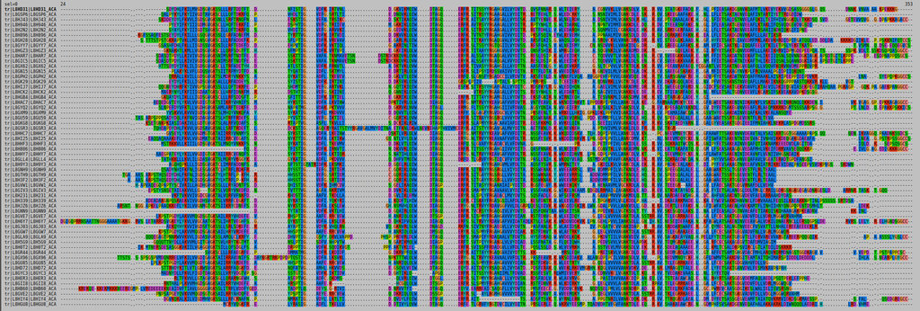

$hmmalign$ alignment of *Acanthamoeba* Rab GTPases.

Note that **$hmmalign$ can only align the regions that overlap with the HMM model**. Therefore, the alignment shown above, covers only the core Rab domain. It is therefore quite notorious that several sequences seem to have deletions within otherwise highly conserved sequence blocks. This is suspicious.

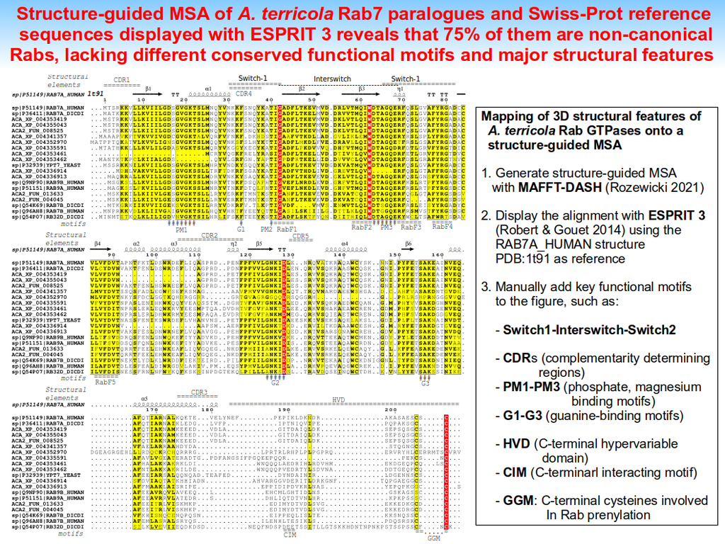

Figure from: [Rivera et al. (2024). Phylogenomic, structural, and cell-biological analyses reveal that Stenotrophomonas maltophilia replicates in acidified Rab7A-positive vacuoles of Acanthamoeba castellanii. Microbiology Spectrum, 2024 Mar 5;12(3):e0298823.](https://pubmed.ncbi.nlm.nih.gov/38319117/). doi: 10.1128/spectrum.02988-23

The following figure shows the prediction we made for the correct *A. castellanii* Rab7A protein, which is critical in membrane trafficking along the phagocytic and autophagic pathways.

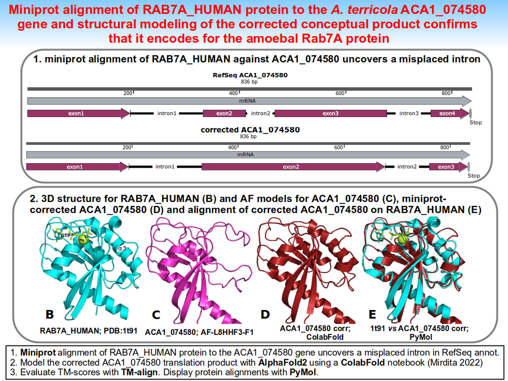

Figure from: [Rivera et al. (2024). Phylogenomic, structural, and cell-biological analyses reveal that Stenotrophomonas maltophilia replicates in acidified Rab7A-positive vacuoles of Acanthamoeba castellanii. Microbiology Spectrum, 2024 Mar 5;12(3):e0298823.](https://pubmed.ncbi.nlm.nih.gov/38319117/). doi: 10.1128/spectrum.02988-23

### 6.4.3 Align the full-length *Acanthamoeba* Rabs using $clustalo$ and the Rab family-specific HMM

As shown in a previous section, $clustalo$ can use externally provided HMMs to aid in the multiple sequence alignment process. Therefore, we can use the Rab.hmm to align the ACACA_Rab_hmmsearch_hits.faa FASTA, generating an **alignment of the full-length sequences**, which is not possible with $hmmalign$.

Furthermore, the MSA produced by $hmmalign$, even after conversion to FASTA format, contains dot characters that are not acceptable in the FASTA format. Therefore, it is certainly convenient to do HMM-guided full-length MSAs with $clustalo$.

```bash
clustalo -i ACACA_Rab_hmmsearch_hits.faa --hmm-in Rab.hmm -o Rab_SPhyd94_plusACA_cluoHMM.afa --threads 4

seaview Rab_SPhyd94_plusACA_cluoHMM.afa &
```

Inspection of the Rab_SPhyd94_plusACA_cluoHMM.afa alignment confirms that it was performed on the full-length sequences. As seen already in the alignment produced with $hmmalign$, several sequences contain suspicious gaps in otherwise highly conserved signature regions.

From these analyses we can conclude that the *A. castellanii* proteome is poorly and inconsistently annotated, and that the gene models (exon-intron structure) of the genome require revision.

## 6.5 Annotating proteins by interrogating the Pfam library of profile HMMs with $hmmscan$

As a final exercise, we will learn how to use $hmmscan$ to search with sequences against a library of HMMs.

We will use the subset of *Acanthamoeba* Rab hits found by $hmmsearch$ with our Rab.hmm model that are longer than 300 residues. These proteins are notably larger than the canonical Rabs used to construct the Rab.hmm model, which are between 200-250 residues, as shown before. We want to know if these larger proteins contain additional domains, and identify them by interrogating the [Pfam A library of profile HMMs for known domains](http://pfam.xfam.org/).

### 6.5.1 Identify and extract *Acanthamoeba* Rab GTPases > 300 amino acids in length from the indexed ACACA.faa proteome using $esl-sfetch$

We will use again the handy $AWK$ script $fasta\_toolkit.awk$ to compute the lengths of each sequence, generating a list of IDs for the sequences that are > 300 residues long, and extract them from the previously indexed ACACA.faa proteome with $esl-sfetch$.

```bash
# print the IDs of Acanthamoeba Rab sequences that are > 300 aa long using fasta_toolkit.awk
#  and filtering its output using cut, sort and awk to generate a sorted list of sequence lengths.
# fasta_toolkit.awk -R 5 ACACA_Rab_hmmsearch_hits.faa | sed '1d' | cut -f1,7 | sort -t $'\t' -nk2,2 | awk -F"\t" '$2 > 300' | cut -d' ' -f1 # <<< v0.5
fasta_toolkit.awk -R 6 ACACA_Rab_hmmsearch_hits.faa | sort -t $'\t' -nk2,2 | awk -F"\t" '$2 > 300' | cut -d' ' -f1

# fetch the > 300 residue-long sequences from the previously indexed Acanthamoeba proteome database using esl-sfetch
# Note the use of the <() (process substitution) Bash idiom to avoid writing intermediary files
esl-sfetch -f ACACA.faa <(fasta_toolkit.awk -R 6 ACACA_Rab_hmmsearch_hits.faa | sort -t $'\t' -nk2,2 | awk -F"\t" '$2 > 300' | cut -d' ' -f1) > ACA_Rab_hits_gt300aa.faa

# the code below would produce the same result as the command shown above, but writing the list of sequences with > 300 residues to the file ACA_Rab_hit_IDs_gt300aa.list
#fasta_toolkit.awk -R 6 ACACA_Rab_hmmsearch_hits.faa | sort -t $'\t' -nk2,2 | awk -F"\t" '$2 > 300' | cut -d' ' -f1 > ACA_Rab_hit_IDs_gt300aa.list
#esl-sfetch -f ACACA.faa ACA_Rab_hit_IDs_gt300aa.list > ACA_Rab_hits_gt300aa.faa
```

### 6.5.2 Scan the *Acanthamoeba* Rab GTPases > 300 amino acids to annotate their Pfam domains using $hmmscan$

Rather than searching a single profile HMM against a collection of sequences, we want to annotate protein sequences by using them as queries to search against a collection of profiles of all known domains and repeats available in [Pfam](http://pfam.xfam.org/).

$hmmscan$ takes as input a query file containing one or more protein sequences to annotate, and a profile database to search them against. The profile database might be Pfam, SMART, or TIGRFams, for example, or another collection of your choice, including custom-made HMMs.

A **profile “database” file** is just a concatenation of individual profile files. To create a database file, you can either build individual profile files and concatenate them, or you can concatenate Stockholm alignments and use $hmmbuild$ to build a profile database from them in one command.

Here we will use the [Pfam A library of profile HMMs for known domains](http://pfam.xfam.org/). The Pfam database is a large collection of protein families, each represented by multiple sequence alignments and hidden Markov models (HMMs), currently (v39.0) holding 53,275 families.

#### 6.5.2.1 Compressing and indexing large HMM text flatfiles (e.g. Pfam-A.hmm) with $hmmpress$

$hmmscan$ has to read a lot of profiles in a hurry, and HMMER’s HMM text flatfiles are bulky. To accelerate this, **$hmmscan$ depends on binary compression and indexing of the flatfiles**. Therefore, before running $hmmscan$, you need to compress and index your profile database with the $hmmpress$ program:

```
hmmpress
your_profile_db
```

I compressed and indexed the Pfam-A.hmm profile database with the following command:

```bash
hmmpress Pfam-A.hmm
```

Remember that we can access the path to the Pfam-A database by interpolating the variable `“${pfam_db}”`, or

```bash
base_dir=/export/space3/users/vinuesa/DBs
sp_db="${base_dir}"/Swiss-Prot
pfam_db="${base_dir}"/Pfam
euk_proteomes="${base_dir}"/euk_proteomes
sequences="${base_dir}"/sequences
```

#### 6.5.2.2 Writing a $hmmscan$ parseable table of per-domain hits with `–domtblout`, and using model-specific cutoffs

When running $hmmscan$ on Pfam, I like to use two very useful options:

1. Saving a parseable table of per-domain hits to file with the `–domtblout` option
2. Filtering the output using model-specific thresholding encoded in the Pfam profiles

```bash
#  hmmscan -h
# hmmscan :: search sequence(s) against a profile database
# HMMER 3.4 (Aug 2023); http://hmmer.org/
# Copyright (C) 2023 Howard Hughes Medical Institute.
# Freely distributed under the BSD open source license.
# - - - - - - - - - - - - - - - - - - - - - - - - - - - - - - - - - - - -
# Usage: hmmscan [-options] <hmmdb> <seqfile>
#... truncated

#Options controlling output:
#  -o <f>           : direct output to file <f>, not stdout
#  --tblout <f>     : save parseable table of per-sequence hits to file <f>
#  --domtblout <f>  : save parseable table of per-domain hits to file <f>
#... truncated
#Options for model-specific thresholding:
#  --cut_ga : use profile's GA gathering cutoffs to set all thresholding
#  --cut_nc : use profile's NC noise cutoffs to set all thresholding
#  --cut_tc : use profile's TC trusted cutoffs to set all thresholding


hmmscan --tblout ACA_Rab_hits_gt300aa_hmmscan_PfamA_tbl_cut_ga.out --domtblout ACA_Rab_hits_gt300aa_hmmscan_PfamA_domtbl_cut_ga.out --noali --notextw --cut_ga "${pfam_db}"/Pfam-A.hmm ACA_Rab_hits_gt300aa.faa
```

The relevant section of the [Pfam userman](https://ftp.ebi.ac.uk/pub/databases/Pfam/current_release/userman.txt) relating to the model-specific thresholding cutoffs is shown below:

```
  GA   Gathering threshold:

       Search threshold to build the full alignment.

       GA lines are the thresholds in bits used in the hmmsearch
       command line.  An example GA line is shown below:

       GA   25.00 15.00;

       The order of the thresholds is sequence, domain

       The corresponding hmmsearch command line for the HMM
       would be:

       hmmsearch -T 25 --domT 15 HMM DB

       The -T option specifies the whole sequence score in bits, and
       the --domT option specifies the per-domain threshold in bits.

  NC   Noise cutoff:

       This field refers to the bit scores of the highest scoring
       match not in the full alignment.

       An example NC line is shown below

       NC   19.50 18.10;

       As with the GA line, this field contains two numbers - the
       first number in the set refers to the highest whole sequence
       score in bits of a match not in the full alignment, and the
       second number specifies the highest per-domain score in bits of
       a match not in the full alignment.  These two scores may not
       refer to the same sequence.

  TC   Trusted cutoff:

       This field refers to the bit scores of the lowest scoring match
       in the full alignment.

       An example TC line is shown below

       TC   23.00 16.10;

       As with the GA line, this field contains two numbers - the
       first set refers to the lowest whole sequence score in bits of
       a match in the full alignment, and the second number specifies
       the lowest per-domain score in bits of a match in the full
       alignment.  These two scores may not refer to the same
       sequence.
```

Below I’m showing the first lines of the ACA_Rab_hits_gt300aa_hmmscan_PfamA_domtbl_cut_ga.out file, which contains 22 fields.

```bash
# display first 40 lines of the file
head -40 ACA_Rab_hits_gt300aa_hmmscan_PfamA_domtbl_cut_ga.out
```

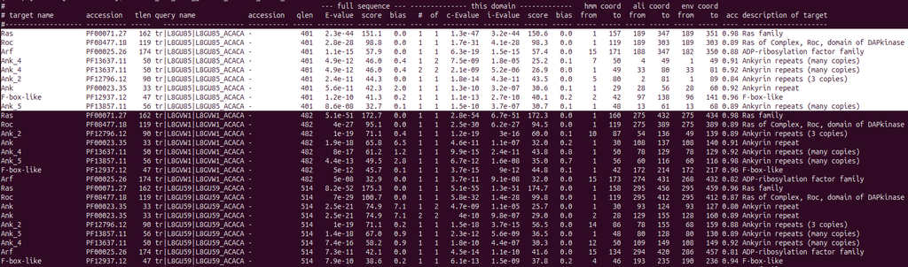

$hmmscan$ domtblout output table of [Pfam domains](http://pfam.xfam.org/) found in long (>300 aa) *Acanthamoeba* Rab GTPases.

In protein search programs, the `–domtblout` option produces the **domain hits table** shown above. There is one line for each domain. There may be more than one domain per sequence, as is the case for all proteins shown above.

The domtblout domain table has 22 space-delimited fields, followed by a free text target sequence description, as follows:

```
(1) **target name**: The name of the target sequence or profile.
(2) **target accession**: Accession of the target sequence or profile, or ’-’ if none is available.
(3) **tlen**: Length of the target sequence or profile, in residues. This (together with the query length) is useful for interpreting where the domain coordinates (in subsequent columns) lie in the sequence.
(4) **query name**: Name of the query sequence or profile.
(5) accession: Accession of the target sequence or profile, or ’-’ if none is available.
(6) **qlen**: Length of the query sequence or profile, in residues.
(7) E-value: E-value of the overall sequence/profile comparison (including all domains).
(8) score: Bit score of the overall sequence/profile comparison (including all domains), inclusive of a null2 bias composition correction to the score.
(9) bias: The biased composition score correction that was applied to the bit score.
(10) #: This domain’s number (1..ndom).
(11) of: The total number of domains reported in the sequence, ndom.
(12) c-Evalue: The “conditional E-value”, a permissive measure of how reliable this particular domain may be.
(13) **i-Evalue**: The “independent E-value”, the E-value that the sequence/profile comparison would have received if this were the only domain envelope found in it, excluding any others. This is a **stringent measure** of how reliable this particular domain may be. It uses the total number of targe…
(14) **score**: The bit score for this domain.
(15) **bias**: The biased composition (null2) score correction that was applied to the domain bit score.
(16) from (hmm coord): The start of the MEA (maximum expected accuracy) alignment of this domain with respect to the profile, numbered 1..N for a profile of N consensus positions.
(17) to (hmm coord): The end of the MEA alignment of this domain with respect to the profile, numbered 1..N for a profile of N consensus positions.
(18) **from (ali coord)**: The start of the MEA alignment of this domain with respect to the sequence, numbered 1..L for a sequence of L residues.
(19) **to (ali coord)**: The end of the MEA alignment of this domain with respect to the sequence, numbered 1..L for a sequence of L residues.
(20) **from (env coord)**: The start of the domain envelope on the sequence, numbered 1..L for a sequence of L residues. The envelope defines a subsequence for which their is substantial probability mass supporting a homologous domain, whether or not a single discrete alignment can be identified.
(21)** to (env coord)**: The end of the domain envelope on the sequence, numbered 1..L for a sequence of L residues.
(22) **acc**: The mean posterior probability of aligned residues in the MEA alignment; a measure of how reliable the overall alignment is (from 0 to 1, with 1.00 indicating a completely reliable alignment according to the model).
(23) description of target: The remainder of the line is the target’s description line, as free text.
```

Since the output has many columns, it is generally useful to parse the per-domain output table file to produce a less detailed but still informative output.

I like to use $AWK$ one-liners for these tasks, like the one provided below, which provides a convenient overview of key parameters.

```bash
awk 'BEGIN{OFS="\t"; print "target\taccession\ttlen\tquery_name\tqlen\tdE-value\tdScore\tDbias\ti-Evalue\tscore\tbias\thmmStart\thmmEnd\tenvStart\tenvEnd\tacc"} !/^#/ {print $1,$2,$3,$4,$6,$7,$8,$9,$13,$14,$15,$16,$17,$20,$21,$22}' ACA_Rab_hits_gt300aa_hmmscan_PfamA_domtbl_cut_ga.out | column -t
```

I use this simplified version of the `–domtblout` so often, that I’ve written a simple $Bash$ wrapper around it, called `simplify_domtblout.sh`. You can [grab $simplify\_domtblout.sh$ from my GitHub repo](https://github.com/vinuesa/TIB-filoinfo/blob/master/simplify_domtblout.sh).

Below the output of the command provided above, showing only the lines corresponding to the first (shortest) and last (largest) query sequences.

```
target      accession   tlen  query_name              qlen  dE-value  dScore  Dbias  i-Evalue  score  bias  hmmStart  hmmEnd  envStart  envEnd  acc
Ras         PF00071.27  162   tr|L8GU85|L8GU85_ACACA  401   2.3e-44   151.1   0.0    3.2e-44   150.6  0.0   1         157     189       351     0.98
Roc         PF08477.18  119   tr|L8GU85|L8GU85_ACACA  401   2.8e-28   98.8    0.0    4.1e-28   98.3   0.0   1         119     189       303     0.89
Arf         PF00025.26  174   tr|L8GU85|L8GU85_ACACA  401   1.1e-15   57.9    0.0    1.5e-15   57.4   0.0   15        171     182       350     0.88
Ank_4       PF13637.11  50    tr|L8GU85|L8GU85_ACACA  401   4.9e-12   46.0    0.4    1.8e-05   25.2   0.1   7         50      1         49      0.91
Ank_4       PF13637.11  50    tr|L8GU85|L8GU85_ACACA  401   4.9e-12   46.0    0.4    5.2e-06   26.9   0.0   1         49      33        81      0.92
Ank_2       PF12796.12  90    tr|L8GU85|L8GU85_ACACA  401   2.4e-11   44.3    0.0    4.3e-11   43.5   0.0   5         80      1         89      0.84
Ank         PF00023.35  33    tr|L8GU85|L8GU85_ACACA  401   5.6e-11   42.3    2.0    3.2e-07   30.6   0.1   1         29      28        60      0.92
F-box-like  PF12937.12  47    tr|L8GU85|L8GU85_ACACA  401   1.2e-10   41.3    0.2    2.7e-10   40.1   0.2   2         42      96        141     0.96
Ank_5       PF13857.11  56    tr|L8GU85|L8GU85_ACACA  401   8.6e-08   32.7    0.1    3.7e-07   30.7   0.1   1         48      13        68      0.89
Ank_3       PF13606.11  30    tr|L8GU85|L8GU85_ACACA  401   6.8e-06   26.3    0.2    0.00047   20.7   0.0   1         28      28        57      0.91
F-box       PF00646.38  43    tr|L8GU85|L8GU85_ACACA  401   7.1e-05   22.8    0.1    0.00013   22.0   0.1   1         42      96        139     0.94
... truncated
Ras         PF00071.27  162   tr|L8HB60|L8HB60_ACACA  988   4.2e-63   212.0   0.0    2.9e-26   92.2   0.1   2         160     18        208     0.83
Ras         PF00071.27  162   tr|L8HB60|L8HB60_ACACA  988   4.2e-63   212.0   0.0    2.7e-32   111.8  0.0   2         160     431       594     0.94
Roc         PF08477.18  119   tr|L8HB60|L8HB60_ACACA  988   9.8e-23   80.9    0.0    1.2e-08   35.4   0.0   2         119     18        153     0.68
Roc         PF08477.18  119   tr|L8HB60|L8HB60_ACACA  988   9.8e-23   80.9    0.0    5.5e-10   39.8   0.0   2         119     431       547     0.79
PH          PF00169.34  105   tr|L8HB60|L8HB60_ACACA  988   4e-21     75.8    1.3    1.2e-12   48.6   0.0   3         104     212       311     0.92
GTP_EFTU    PF00009.32  188   tr|L8HB60|L8HB60_ACACA  988   1e-20     74.4    0.0    4.9e-11   42.8   0.0   5         186     15        208     0.84
GTP_EFTU    PF00009.32  188   tr|L8HB60|L8HB60_ACACA  988   1e-20     74.4    0.0    1.1e-06   28.7   0.0   18        186     384       594     0.80
MMR_HSR1    PF01926.28  113   tr|L8HB60|L8HB60_ACACA  988   7.3e-14   52.1    0.1    0.00017   21.9   0.0   1         99      18        151     0.62
MMR_HSR1    PF01926.28  113   tr|L8HB60|L8HB60_ACACA  988   7.3e-14   52.1    0.1    7.8e-06   26.3   0.0   1         86      431       545     0.72
Arf         PF00025.26  174   tr|L8HB60|L8HB60_ACACA  988   1.5e-13   50.8    0.0    3.9e-06   26.7   0.0   16        172     422       608     0.82
```

As expected, both proteins (L8GU85_ACACA and L8HB60_ACACA) have strong hits to the Ras profile HMM model, and notably weaker hits to domains of other Ras superfamily members that overlap (see envStart and envEnd) with the Ras domain hit coordinates on the query.

Note that the Ras domain hit has the largest score, although the model length (tlen) is not the largest one.

However, the first (shortest) sequence (L8GU85_ACACA) contains multiple **Ankyrin repeats**, and an **F-box like** domain on its N-terminal extension.

The last (largest) sequence (L8HB60_ACACA), interestingly, seems to be a fusion protein containing **two Ras domains** located at positions 18-208 and 431-594 of the 988 residue-long protein, separated by a **PH domain** (Pleckstrin homology) located between positions 212-311. This is certainly **not a canonical Rab GTPase**. In addition, as we found when validating hits for prenylation sites, **L8HB60 does not contain cysteines among its five C-terminal residues**.

You can interrogate [**IntePro**](https://www.ebi.ac.uk/interpro/) with a PFAM accession to find out more about its function and structure.

For example:

- [**PF00023**](https://www.ebi.ac.uk/interpro/entry/pfam/PF00023/): **(ANK) Ankyrins** are **multifunctional adaptors that link specific proteins to the membrane-associated, spectrin-actin cytoskeleton**. This repeat-domain is a ‘membrane-binding’ domain of up to 24 repeated units, and it mediates most of the protein’s binding activities. Repeats 13-24 are especially active, with known sites of interaction for the Na/K ATPase, Cl/HCO(3) anion exchanger, voltage-gated sodium channel, clathrin heavy chain, and L1 family cell adhesion molecules. The ANK repeats are found to form a contiguous spiral stack such that ion transporters like the anion exchanger associate in a large central cavity formed by the ANK repeat spiral, while clathrin and cell adhesion molecules associate with specific regions outside this cavity.
- [**PF12937**](https://www.ebi.ac.uk/interpro/entry/InterPro/IPR001810/): **F-box-like domain** First identified in cyclin-F as a **protein-protein interaction motif**, the F-box is a conserved domain that is present in numerous proteins with a bipartite structure Through the F-box, these proteins are linked to the Skp1 protein and the core of SCFs (Skp1-cullin-F-box protein ligase) complexes. SCFs complexes constitute a new class of E3 ligases. They function in combination with the E2 enzyme Cdc34 to ubiquitinate G1 cyclins, Cdk inhibitors and many other proteins, to mark them for degradation. The binding of the specific substrates by SCFs complexes is mediated by divergent protein-protein interaction motifs present in F-box proteins, like WD40 repeats, leucine rich repeats or ANK repeats.
- [**PF00169**](https://www.ebi.ac.uk/interpro/entry/pfam/PF00169/): **Pleckstrin homology (PH) domain** or (PHIP) is a protein domain of approximately 120 amino acids that **occurs in a wide range of proteins involved in intracellular signaling or as constituents of the cytoskeleton**.

Note that each of these Pfam entries has references to the relevant papers not shown in the output presented above.

### 6.5.3 Display of protein structures with PyMOL

Another useful skill to to have for studying protein domains is to be able to display them in customized ways. Here I will show how to display a protein using [PyMOL](https://pymol.org/), a user-sponsored molecular visualization system on an open-source foundation, maintained and distributed by Schrödinger. [Here is the PyMOL Wiki](https://pymolwiki.org/index.php/Main_Page).

Another popular molecular graphics visualization program is [RasMol](http://www.openrasmol.org/), originally developed by Roger Sayle. [Here is the RasMol manual](http://www.rasmol.org/software/RasMol_Latest_Manual.html).

#### 6.5.3.1 Fetching AlphaFold structures from [AlphaFoldDB](https://alphafold.ebi.ac.uk/)

First we need to fetch them the structures for the L8GU85 and L8HB60 *Acanthamoeba* proteins. You can explore them on UniProt: [L8GU85](https://www.uniprot.org/uniprotkb/L8GU85/entry), [L8HB60](https://www.uniprot.org/uniprotkb/L8HB60/entry), and fetch them directly from there.

We can fetch the structures predicted by AlphaFold for both proteins from the [AlphaFoldDB](https://alphafold.ebi.ac.uk/) with the following commands:

```bash
# fetch the "shortest" protein L8GU85 and remove the HTML header section
wget -c https://alphafold.ebi.ac.uk/files/AF-L8GU85-F1-model_v6.pdb

# fetch the "largest" protein L8HB60 and remove the HTML header section
wget -c https://alphafold.ebi.ac.uk/files/AF-L8HB60-F1-model_v6.pdb
```

#### 6.5.3.2 Renedering structures with PyMOL

Now let us prepare two coordinate tables for the best-scoring, non-overlapping domains found in our $hmmscan$ search against the Pfam-A profile database.

Based on the *tbldomout* output table shown above, I have written the best-scoring, non-overlapping domains for each protein in two separate tab-delimited files. Its contents are shown below:

```
# best-scoring, non-overlapping domains for L8GU85
Ras 189 351
Ank_2   1   89
F-box-like  96  141
```

```
# best-scoring, non-overlapping domains for L8HB60
Ras1    18  208
Ras2    431 594
PH  212 311
```

- [PyMOLWiki - command page](https://pymolwiki.org/index.php/Category:Commands)
- [PyMOLWik - list of named colors to RBG codes](https://pymolwiki.org/index.php/Color_Values)

Note that the command `set_color color-name, [r,b,g]` requires the colors to be coded as RBG values between 0 and 1.

Below the PyMOL code for rendering the domains in L8GU85, which should be typed into the PyMOL command prompt.

```bash
# load PyMOL
pymol &

# let's write a PyMOL pml script (logfile) that will hold all commands executed on the PyMOL prompt
#File > logfile > open > L8GU85.pml
log_open L8GU85.pml

# Load the protein structure file
load AF-L8GU85-F1-model_v6.pdb

# Render as cartoon with fancy helices
as cartoon
set cartoon_fancy_helices, 1

# Color protein backbone in gray60
color gray60

# Define and set alternating domain colors
select Ras, resi 189-351
color firebrick, Ras
select Ank_2, resi 1-89
color limon, Ank_2
select F-box-like, resi 96-141
color violetpurple, F-box-like
deselect

# Highlight N- and C- terminal residues
show spheres, resi 1
color red, resi 1  # N-terminus in red
show spheres, resi 401
color blue, resi 401   # C-terminus in blue

# Highlight C398 (potential prenylation site) as yellow sticks
show sticks, resi 398 # show cysteine 398 in the C-terminal region as sticks
color yellow, resi 398

# Turn and resize the structure as you desire and then save as png file to disk
ray 1500
png L8GU85_with_colored_Pfam_domains.png

log_close
quit
```

And here the PyMOL code for rendering L8HB60:

```bash
# Load the protein structure file
load AF-L8HB60-F1-model_v6.cif

# Render as cartoon with fancy helices
as cartoon
set cartoon_fancy_helices, 1

# Color protein backbone as gray60
color gray60

# Define and set alternating domain colors
select Ras_like, resi 18-208
color orange, Ras_like
select Ras, resi 431-594
color firebrick, Ras
select PH, resi 212-311
color yellow, PH
deselect

# Highlight N- and C- terminal residues
show spheres, (resi 1)
color blue, (resi 1)  # N-terminal in blue
show spheres, (resi 988)
color red, (resi 988)   # C-terminal in red

# Turn and resize the structure as you desire and then save as png file to disk
ray 1500
png L8HB60_with_colored_Pfam_domains.png
```

We can run these lines from within $PyMOL$, or save them as $PyMOL$ script (.pml) files and call them directly from $PyMOL$. Once loaded, we tweak the output a bit to set the colors as we like, as shown in the following screenshot:

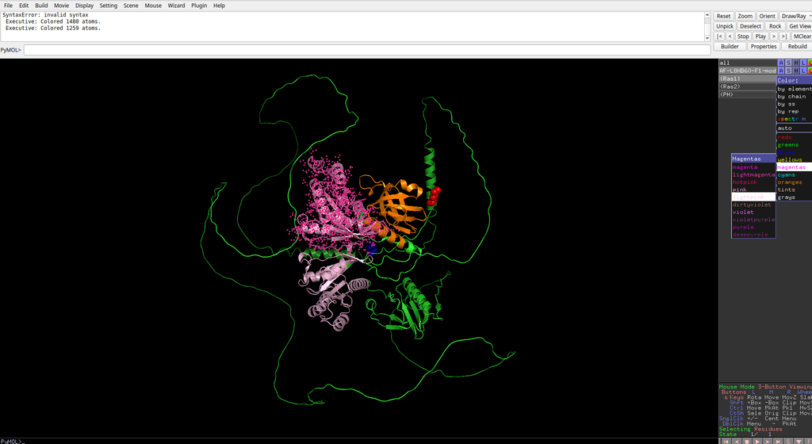

Using PyMOL to render a protein structure and highlight Pfam domains in distinct colors.

- Final $PyMOL$ rendering for AF-L8GU85-F1 (L8GU85 Rab, 401 aa):

[figure not shown]

  PyMOL rendering of AF-L8GU85-F1 with the Ank_2 (“yellow”), F-box-like (“magenta”), and Ras (“firebrick”) Pfam domain highlighted in distinct colors.

- Final $PyMOL$ rendering for the largest *Acanthamoeba* Rab GTPase (L8HB60, 988 aa):

[figure not shown]

  PyMOL rendering of AF-L8HB60-F1 with the Ras_like (“oragne”), PH (“limon”), and Ras2 (“firebrick”) Pfam domain highlighted in distinct colors.

## 6.6 HMMER exercise

Perform the following tasks, documenting the commands used, and results obtained, in a fashion similar to that used throughout this tutorial

1. Identify, count, and extract the *bona fide* Rab GTPase hits for *Arabidopsis thaliana* and *Caenorhabditis elegans* found in the $hmmsearch$ run performed on the Swiss-Prot database (uniprot_sprot.fasta file)
2. Inspect the hits for length and presence of at least one cysteine at their C-termini, document and remove any suspicious ones, add the *bona fide* ones to the Rab_SPhyd94.faa file, and align the extended FASTA using $clustalo$ with two iterations and Kimura-corrected distances
3. Manually inspect the MSA from the previous step, remove flanking regions containing mostly gapped sites that accommodate the N- and C-terminal extensions found in some proteins, and build a new Rab-family HMM from the trimmed MSA
4. Calibrate the new model by interrogating the Swiss-Prot sequences. What would you suggest is a reasonable sequence score cutoff for this new HMM? Present evidence in a fashion similar to that used in previous sections of this tutorial.
5. Using the new model and score cutoff, how many canonical Rab GTPases are found for *Danio rerio*, *Bos taurus*, and *Canis familiares* when interrogating the uniprot_sprot.fasta file?

# 7 Recommended readings and references

## 7.1 Multiple sequence and HMM-HMM alignments

- [Katoh K. ed. (2021). Multiple sequence alignment - methods and protocols. MIMB, volume 2231](https://link.springer.com/book/10.1007/978-1-0716-1036-7)
- [Clustal family - wikipedia](https://en.wikipedia.org/wiki/Clustal)
- [Multiple sequence alignments - wikipedia](https://en.wikipedia.org/wiki/Multiple_sequence_alignment)

## 7.2 Clustal-omega

- [Clustal.org](http://www.clustal.org/)
- Sievers et al. 2011. Fast, scalable generation of high-quality protein multiple sequence alignments using Clustal Omega. [Mol Syst Biol. 2011 Oct 11:7:539. doi: 10.1038/msb.2011.75](https://www.embopress.org/doi/full/10.1038/msb.2011.75)
- Sievers & Higgins 2018. Clustal Omega for making accurate alignments of many protein sequences. [Protein Sci. 2018. Jan;27(1):135-145. doi: 10.1002/pro.3290](https://onlinelibrary.wiley.com/doi/10.1002/pro.3290)
- Sievers & Higgins 2014. [Clustal Omega. Current Protocols in Bioinformatics](https://currentprotocols.onlinelibrary.wiley.com/doi/10.1002/0471250953.bi0313s48)

## 7.3 Profile hidden Markov models and HMMER3

- Sean R Eddy (1998). Profile hidden Markov models. [Bioinformatics 14(9):755-63](https://doi.org/10.1093/bioinformatics/14.9.755)
- Sean R Eddy (2004). What is a hidden Markov model? [Nat Biotechnol 22(10):1315-6](https://www.nature.com/articles/nbt1004-1315)
- Söding J. (2005). Protein homology detection by HMM-HMM comparison. [Bioinformatics 21(7):951-60](https://doi.org/10.1093/bioinformatics/bti125)
- Sean R Eddy (2011). Accelerated Profile HMM Searches. [PLoS Comput Biol; 7(10):e1002195](https://journals.plos.org/ploscompbiol/article?id=10.1371/journal.pcbi.1002195)
- [HMMER.org](http://hmmer.org/)
- [HMMER3.4 user guide](http://eddylab.org/software/hmmer/Userguide.pdf)

## 7.4 The Ras superfamily of GTPases, and Rab GTPases in *Acanthamoeba castellanii*

- Krister Wennerberg, Kent L Rossman, Channing J Der (2005). The Ras superfamily at a glance. [J Cell Sci. 2005 Mar 1;118(Pt 5):843-6. doi:10.1242/jcs.01660.](https://journals.biologists.com/jcs/article/118/5/843/28805/The-Ras-superfamily-at-a-glance)
- Stenmark H. (2009). Rab GTPases as coordinators of vesicle traffic. [Nature Reviews Molecular Cell Biology volume 10, 513-525.](https://www.nature.com/articles/nrm2728)
- Javier Rivera, Julio C. Valerdi-Negreros, Diana M. Vázquez-Enciso, Fulvia-Stefany Argueta-Zepeda, Pablo Vinuesa* 2024. Phylogenomic, structural, and cell-biological analyses reveal that *Stenotrophomonas maltophilia* replicates in acidified Rab7A-positive vacuoles of *Acanthamoeba castellanii*. [Microbiology Spectrum Mar 5;12(3):e0298823](https://journals.asm.org/doi/10.1128/spectrum.02988-23).